# Jupyter tutorial

@surchs

# What to expect

- What is a notebook and why do I want that
- What is a conda environment (also: why do I want that)
- How can I install and run it on my machine
- What pitfalls do I need to avoid
- Where do I go for additional support

There is a readme file that covers most of these steps as well in the git repo: https://github.com/mtl-brainhack-school-2018/teaching_material

# What you need

Anaconda python distribution installed. Get it here: https://www.anaconda.com/download/

You can also make your own virtual environments. Conda is easier if you:

- don't have administrative rights on your machine (but see containers tomorrow)
- are new to the command line and like to have a graphical interface (make sure you get Anaconda, not miniconda)
- don't want to or can't deal with installing system dependencies (conda gets most for you)
- you are on Windows (pretty much the only option for you then)

# What is a notebook

A Jupyter notebook is an interactive way to run code through your browser

[figure not shown]

# Why do I want a notebook

Great way to try out ideas and immediately see what happens.

```python
import numpy as np
```

```python
some_array = np.zeroes(10)
```

```
---------------------------------------------------------------------------
AttributeError                            Traceback (most recent call last)
<ipython-input-6-3b55f5379a86> in <module>()
----> 1 some_array = np.zeroes(10)

AttributeError: module 'numpy' has no attribute 'zeroes'
```

```python
# Preposterous
some_array = np.zeros(10)
```

# Why do I want a notebook

Get perpetual visual output.

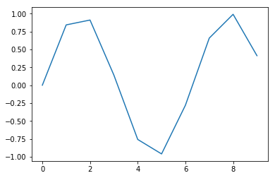

```python
from matplotlib import pyplot as plt
x = np.arange(10)
y = np.sin(x)
plt.plot(x, y)
plt.show()
```

# Why do I want a notebook

Easy to annotate code and findings with markdown (great for sharing). Also great for reproducing your work. See also https://nbviewer.jupyter.org/

[figure not shown]

# Why do I want a notebook

You can run code on a remote machine.

- no need to move data around
- only need a web browser
- good for that last minute analysis while traveling to a conference

[figure not shown]

# How do I install

Don't use your system python. Use Conda (virtual) environments.

1. Open a new terminal
2. [Create a new conda environment](https://conda.io/docs/user-guide/tasks/manage-environments.html#creating-an-environment-with-commands) for jupyter notebook: `conda create --name jpserver`
3. [Check the available conda environments](https://conda.io/docs/user-guide/tasks/manage-environments.html#viewing-a-list-of-your-environments): `conda env list`. You should see the new `jpserver` environment in the list.
4. [Activate the new environment](https://conda.io/docs/user-guide/tasks/manage-environments.html#activating-an-environment) `source activate jpserver`
5. This is an empty conda environment, with nothing in it: `conda list --name jpserver`. We need to install python first: `conda install --name jpserver python`

# How do I install jupyter notebook

Use Conda environments.

1. Now we can [install the jupyter packages](https://conda.io/docs/user-guide/tasks/manage-pkgs.html#installing-packages) in this environment: `conda install --name jpserver jupyter jupyterlab`
2. Move to your home directory or some other directory that you would like the server to have access to: `cd ~/`
3. Start the jupyter lab server `jupyter lab`

This should open a new browser window with the jupyter lab layout.

# Get a conda environment for your project

Don't run everything in your jupyter environment.

1. Create a new conda environment for your current project (e.g. `brainhack`) but this time request that python is installed directly: `conda create --name brainhack python`. You can confirm that python was in fact installed (with some additional tools) by running `conda list --name brainhack`
2. Now install `ipykernel` so we can make jupyter aware of your new environment: `conda install --name brainhack ipykernel`
3. Activate the environment with `source activate brainhack`
4. [Register your new environment with jupyter](https://ipython.readthedocs.io/en/latest/install/kernel_install.html#kernels-for-different-environments): `python -m ipykernel install --user --name brainhack --display-name "python brainhack"`

Go back to your notebook server and check for the new kernel

# You can install non-python kernels as well

The nice thing about jupyter is that it can run a long list of interpreters. Have a look [here](https://github.com/jupyter/jupyter/wiki/Jupyter-kernels) for a long list.

[figure not shown]

# Install packages in your project environment

1. Ask conda to install the packages (e.g. `numpy` and `matplotlib`): `conda install --name brainhack numpy matplotlib`.
2. Go to your jupyter lab website that is running in the `jpserver` environment and [start a new notebook](http://jupyterlab.readthedocs.io/en/latest/user/notebook.html) with the `brainhack` kernel.
3. Confirm that you can access the newly installed packages by running `import numpy as np` and executing the cell (`Shift + Enter`). If you don't get an error message you are good to go

# Install packages not available through conda

You have two options here:

1. [See if the package is available from a conda channel](https://conda.io/docs/user-guide/tasks/manage-pkgs.html#installing-packages-from-anaconda-org). These channels are additional repositories maintained by community members. I don't know how reliable they are.
2. Install them directly from the [Python Package Index](https://conda.io/docs/user-guide/tasks/manage-pkgs.html#installing-non-conda-packages). The Python Package Index or pypi is a central hosting platform for python packages. Most packages are available from there. You can [install them using `pip`.](https://pip.pypa.io/en/stable/user_guide/#installing-packages).
   - When you use pip, you need to first activate your environment: `source activate brainhack`
   - `pip install nilearn nibabel`

# Pitfalls

There are two main things to look out for:

- jupyter cells share variable names. That means the output of your cells can change depending on the order in which you run them

```python
message = 'Jupyter is cool'
print(message)
```

```
Jupyter is cool
```

```python
message = 'Brainhack is cool'
```

```python
print(message)
```

```
Brainhack is cool
```

- You should never try to install python packages from inside the notebook. See [this post for a long explanation](https://jakevdp.github.io/blog/2017/12/05/installing-python-packages-from-jupyter/).

# Summary

Jupyter notebooks are great for:

- trying out things
- seeing results immediately
- (poor man's) debugging
- annotating results
- sharing results
- running things on a remote machine

Not great for:

- version control
- strictly linear execution